# Weather Impact Analysis

How weather conditions affect `arrival_delay`: rain, heavy rain, wind, snow and temperature.

## Setup

```python
from zh_tram_flow.notebook import *
import zh_tram_flow.analytics.meteo as an

TRAIN, TEST, lf, lf_all, lf_delay, lf_clean = setup_analysis("03_analysis_5-meteo")

%load_ext autoreload
%autoreload 2
```

```
✓  wgnd theme activated (matplotlib · seaborn)
```

```
2026-06-11 15:45:42  INFO      project  03_analysis_5-meteo started
```

```
The autoreload extension is already loaded. To reload it, use:
  %reload_ext autoreload
```

## Wetterübersicht — alle Faktoren im Vergleich

Vergleich aller binären Wetterbedingungen auf einen Blick: Regen, starker Regen, Wind, Schnee — jeweils True vs. False. Zeigt welcher Faktor den grössten Einfluss hat.

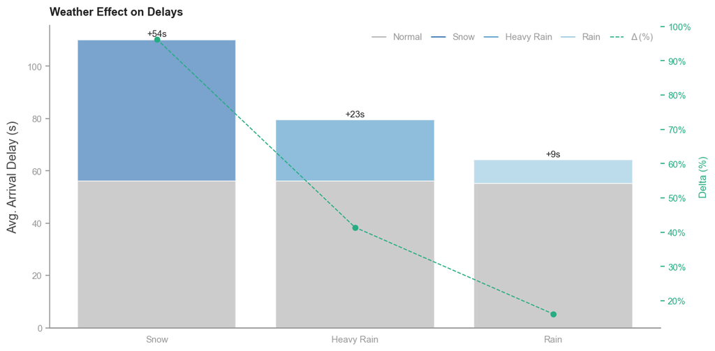

| Wetterbedingung | Δ Delay (s) | OTP Normal | OTP Wetter | N (Wettertage) |
| --- | --- | --- | --- | --- |
| Rain | 8.90 | 87.4% | 84.3% | 10,152,819 |
| Heavy Rain | 23.30 | 87.0% | 79.4% | 228,193 |
| Snow | 54.00 | 87.1% | 76.1% | 273,151 |

```python
an.plot_weather_overview(lf_delay, cfg)

show_df(an.table_weather_overview(lf_delay))
```

**Beobachtung:** Schnee hat den stärksten Einzeleffekt (+54.0s, OTP −10.9pp), gefolgt von Starkregen (+23.3s). Leichter Regen ist messbar aber moderat (+8.9s).

**`is_windy` — Feature-Idee, aber nicht nutzbar:** Wind als Feature wurde untersucht, zeigt aber NaN in der gesamten Analyse. Ursache: Das Feature war in der Datenvorbereitung als Feature-Idee vorgesehen, wurde aber nie korrekt befüllt (vermutlich keine Tage mit Wind > 40km/h im Datensatz, oder das Feature wurde nie in die parquet-Dateien geschrieben). Inhaltlich: Zürich ist durch Bebauung und Hügellagen relativ windgeschützt. Trams sind schwer und auf Schienen gebunden — Wind unter ~60 km/h hat kaum messbaren Betriebseffekt. **`is_windy` wird aus dem Feature-Set entfernt.** (→ F-WEAT-03)

**Wetter-Effekte im Überblick (3 valide Features):**

| Bedingung | Δ Delay (s) | OTP Normal | OTP Wetter | N |
| --- | --- | --- | --- | --- |
| Regen | +8.9 | 87.4% | 84.3% | 10.2M |
| Starkregen | +23.3 | 87.0% | 79.4% | 228k |
| **Schnee** | **+54.0** | **87.1%** | **76.1%** | 273k |

**Wichtige Einschränkung:** Das ist reine Korrelation, keine Kausalität. Alle Wetter-Features haben niedrige Korrelation mit `arrival_delay` (max 0.042). Wetter alleine erklärt wenig Varianz — Wetter-Features bleiben aber als schwache eigenständige Signale im Modell.

→ Wetter-Flags behalten: `has_snow`, `precipitation`, `has_rain`, `has_heavy_rain`; `is_windy` entfernen; Multikollinearität mit Monat/Saison beachten.

## Temperatur — Kontinuierlicher Effekt

Temperatur in 5°C-Bins: zeigt ob der Effekt linear ist oder ob es Schwellwerte gibt (z.B. Frost unter 0°C).

**Ø Delay nach Temperaturbereich (5°C-Bins):**

| Temperatur | Ø Delay (s) | OTP |
| --- | --- | --- |
| −5–0°C | 54.5 | 88.9% |
| **0–5°C** | **53.8** | **88.1%** (niedrigster Delay!) |
| 5–10°C | 55.4 | 87.4% |
| 15–20°C | 56.7 | 86.8% |
| 25–30°C | 59.7 | 85.3% |
| 35–40°C | 64.0 | 84.6% (n=15k — wenige Daten) |

**Kernbefund:** Die Kälte-Hypothese ist falsch — 0–5°C ist die beste Temperaturzone. Wärme verschlechtert die Pünktlichkeit graduell. Aber der Gesamteffekt ist klein: `is_hot` (>20°C) bringt nur **+2.0s Delta** (55.8s vs. 57.8s, OTP −1.1pp) — im Kontext aller Features ein schwaches Signal.

**Warum mehr Delay bei Wärme?**

- Sommer = mehr Freizeitverkehr, Tourismus, Events → vollere Trams, längere Boardingzeiten
- Gleisausdehnung bei Extremhitze (>30°C) → VBZ-Langsamfahrstellen (klassisches Problem)
- Im 35–40°C-Bin (n=15k) ist der Effekt am stärksten, aber die Datenbasis ist sehr dünn

**Kälte profitiert:** Konsistent mit F-TEMP-06 (Winter = beste Jahreszeit). Mögliche Ursache: weniger MIV bei Schnee/Frost kompensiert Halte-Verzögerungen.

→ `temperature` als kontinuierliches Feature; `is_hot` (>20°C) als binärer Flag; Effekt ist real aber klein (+2s) — nicht überbewerten.

## Feature: `is_hot`

Validierung des `is_hot`-Flags (temperature > 20°C) — binäre Vereinfachung des nicht-linearen Temperatureffekts für das Modell (F-WEAT-04).

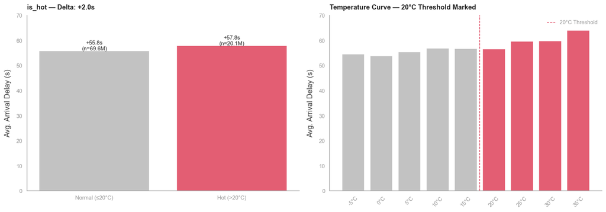

```
Normal (≤20°C): Ø +55.8s  OTP 87.3%  (n=69.6M)
Heiss  (>20°C): Ø +57.8s  OTP 86.2%  (n=20.1M)
→ Delta is_hot: +2.0s
```

| is_hot | Avg. Delay (s) | Median (s) | OTP | N Halte |
| --- | --- | --- | --- | --- |
| Normal (≤20°C) | 55.80 | 42.00 | 87.3% | 69,599,631 |
| Heiss (>20°C) | 57.80 | 44.00 | 86.2% | 20,115,270 |

```python
an.plot_is_hot(lf_delay, cfg, ylim_compare=(0, 70), ylim_curve=(0,70))
show_df(an.table_is_hot(lf_delay))
```

**Beobachtung:** Das `is_hot`-Feature (temperature > 20°C) validiert sich sauber.

**is_hot Vergleich:**

[output not shown]

## Daily Delay Timeline — Weather Events

Täglicher Delay-Verlauf pro Jahr — Schnee, Starkregen und Hitze als farbige Marker. Zeigt ob Delay-Spitzen mit Wetterereignissen zusammenfallen.

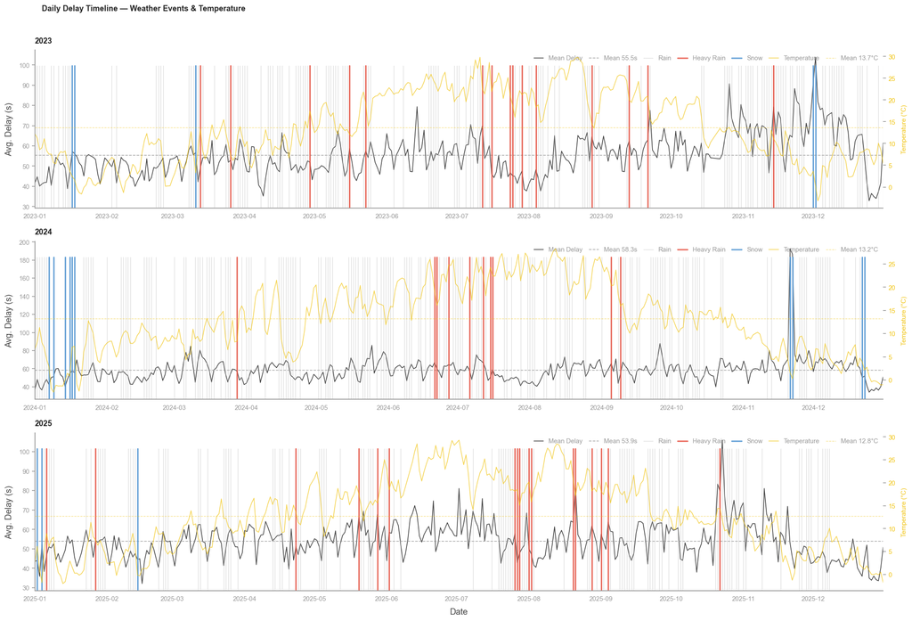

|  | Datum | Wetter | Avg. Delay (s) | OTP | N Halte |
| --- | --- | --- | --- | --- | --- |
| 0 | 2024-11-21 00:00:00 | Snow | 404.60 | 42.1% | 27789 |
| 1 | 2024-11-22 00:00:00 | Snow | 149.10 | 54.7% | 14290 |
| 2 | 2025-09-01 00:00:00 | Heavy Rain | 145.50 | 62.4% | 4187 |
| 3 | 2023-12-01 00:00:00 | Snow | 136.60 | 60.3% | 18823 |
| 4 | 2024-07-12 00:00:00 | Heavy Rain | 132.00 | 66.1% | 4236 |
| 5 | 2025-07-26 00:00:00 | Heavy Rain | 131.20 | 66.8% | 4389 |
| 6 | 2023-11-14 00:00:00 | Heavy Rain | 119.50 | 60.5% | 4469 |
| 7 | 2025-09-04 00:00:00 | Heavy Rain | 113.00 | 68.7% | 4895 |
| 8 | 2025-10-22 00:00:00 | Heavy Rain | 111.40 | 67.3% | 9967 |
| 9 | 2024-09-05 00:00:00 | Heavy Rain | 99.30 | 70.8% | 4750 |
| 10 | 2024-06-21 00:00:00 | Heavy Rain | 93.30 | 71.7% | 4897 |
| 11 | 2024-04-15 00:00:00 | Hitze | 92.40 | 70.3% | 3677 |
| 12 | 2023-06-14 00:00:00 | Hitze | 91.40 | 73.6% | 45372 |
| 13 | 2025-01-04 00:00:00 | Snow | 91.20 | 75.6% | 26710 |
| 14 | 2023-07-12 00:00:00 | Heavy Rain | 90.50 | 75.9% | 13162 |
| 15 | 2023-12-02 00:00:00 | Snow | 89.50 | 74.0% | 42449 |
| 16 | 2023-09-21 00:00:00 | Heavy Rain | 89.10 | 71.5% | 3301 |
| 17 | 2025-07-31 00:00:00 | Hitze | 87.00 | 77.4% | 40587 |
| 18 | 2025-07-12 00:00:00 | Hitze | 82.90 | 76.6% | 60761 |
| 19 | 2025-07-02 00:00:00 | Hitze | 82.50 | 74.8% | 81762 |
| 20 | 2025-06-21 00:00:00 | Hitze | 81.50 | 76.9% | 63793 |
| 21 | 2024-07-09 00:00:00 | Hitze | 81.10 | 76.5% | 69831 |
| 22 | 2025-04-05 00:00:00 | Hitze | 79.70 | 72.9% | 22532 |
| 23 | 2024-09-07 00:00:00 | Hitze | 79.40 | 78.0% | 57976 |
| 24 | 2023-10-07 00:00:00 | Hitze | 79.10 | 76.0% | 18862 |
| 25 | 2024-01-18 00:00:00 | Snow | 70.00 | 80.6% | 13040 |
| 26 | 2023-01-17 00:00:00 | Snow | 67.70 | 81.4% | 4600 |
| 27 | 2023-01-18 00:00:00 | Snow | 58.10 | 86.8% | 31699 |
| 28 | 2024-12-22 00:00:00 | Snow | 55.80 | 86.6% | 10422 |
| 29 | 2024-01-09 00:00:00 | Snow | 55.20 | 86.6% | 6622 |

```python
an.plot_daily_delay_weather_timeline(lf_all, cfg)
show_df(an.table_daily_delay_weather_timeline(lf_clean))
```

**Beobachtung:** Der tägliche Delay-Verlauf zeigt klare Wetter-Signaturen — aber Schnee-Tage ragen als Spitzen heraus, während Regen eher ein erhöhtes Grundrauschen erzeugt.

**Temperatur** (gelbe Linie): Im Winter (niedrige Temperatur) sind die Delays tendenziell niedriger — konsistent mit F-WEAT-04. Sommerhitze (+20°C) korreliert mit leicht erhöhtem Grundniveau.

**Wichtige Einschränkung:** Wetter erklärt nicht alle Spitzen — Events (Berufsmesse, Stadtfest) können ähnliche Delay-Peaks erzeugen ohne Wetter-Marker. Die Kombination beider Notebooks ist nötig für eine vollständige Erklärung der Delay-Spitzen.

→ Schnee = scharfe, isolierte Peaks. Regen = diffuse Erhöhung. Wetter alleine erklärt die Varianz nicht vollständig (r < 0.05).

## Weather Impact Map — Stop Level

Δ Delay pro Haltestelle an Schnee- und Starkregen-Tagen vs. Normaltagen. Zeigt ob bestimmte Stadtteile oder Korridore besonders wetterempfindlich sind.

> **Warum Δ (Delta)?** Haltestellen haben sehr unterschiedliche Basis-Delays — eine Endhaltestelle hat strukturell mehr Delay als eine Innenstadthaltestelle. Δ = Wetter-Delay minus Normal-Delay macht Haltestellen vergleichbar: es zeigt den *zusätzlichen* Effekt des Wetters, unabhängig vom strukturellen Niveau.

```python
an.plot_weather_stop_map(lf_clean, flag="has_snow")
show_df(an.table_weather_stop_map(lf_clean, flag="has_snow"))
```

|  | Stop | District | Normal (s) | Schnee (s) | Δ (s) | N Halte |
| --- | --- | --- | --- | --- | --- | --- |
| 0 | Zürich, Bahnhof Selnau | Kreis 1 | 54.90 | 246.50 | 191.60 | 971 |
| 1 | Zürich, Helvetiaplatz | Kreis 4 | 58.50 | 176.50 | 117.90 | 867 |
| 2 | Zürich, Bahnhof Hardbrücke | Kreis 4 | 60.30 | 178.20 | 117.90 | 847 |
| 3 | Zürich, Hardplatz | Kreis 4 | 61.00 | 177.60 | 116.60 | 855 |
| 4 | Zürich, Bäckeranlage | Kreis 4 | 62.80 | 175.10 | 112.30 | 864 |
| 5 | Zürich, Waidfussweg | Kreis 10 | 45.40 | 155.80 | 110.40 | 701 |
| 6 | Zürich, Güterbahnhof | Kreis 4 | 52.30 | 161.30 | 108.90 | 855 |
| 7 | Zürich, Alte Trotte | Kreis 10 | 53.80 | 160.10 | 106.30 | 703 |
| 8 | Zürich, Eschergutweg | Kreis 10 | 40.20 | 145.40 | 105.20 | 702 |
| 9 | Zürich, Uetlihof | Kreis 3 | 57.40 | 162.00 | 104.60 | 909 |
| 10 | Zürich, Rentenanstalt | Kreis 2 | 50.60 | 155.00 | 104.40 | 774 |
| 11 | Zürich, Laubegg | Kreis 3 | 53.60 | 154.90 | 101.30 | 920 |
| 12 | Zürich, Bahnhof Enge | Kreis 2 | 53.40 | 152.20 | 98.80 | 1508 |
| 13 | Zürich, Tunnelstrasse | Kreis 2 | 53.50 | 149.20 | 95.70 | 2044 |
| 14 | Zürich, Wipkingerplatz | Kreis 10 | 44.70 | 134.80 | 90.10 | 784 |
| 15 | Zürich, Saalsporthalle | Kreis 3 | 55.70 | 142.90 | 87.30 | 1193 |
| 16 | Zürich, Meierhofplatz | Kreis 10 | 59.80 | 146.40 | 86.70 | 883 |
| 17 | Zürich, Schwert | Kreis 10 | 56.00 | 142.70 | 86.70 | 884 |
| 18 | Zürich, Wartau | Kreis 10 | 45.90 | 132.30 | 86.40 | 869 |
| 19 | Zürich, Zwielplatz | Kreis 10 | 56.40 | 142.70 | 86.30 | 877 |

```python
an.plot_weather_stop_map(lf_clean, flag="has_heavy_rain")
show_df(an.table_weather_stop_map(lf_clean, flag="has_heavy_rain"))
```

|  | Stop | District | Normal (s) | Starkregen (s) | Δ (s) | N Halte |
| --- | --- | --- | --- | --- | --- | --- |
| 0 | Zürich, Toni-Areal | Kreis 5 | 55.30 | 99.80 | 44.50 | 701 |
| 1 | Zürich, Technopark | Kreis 5 | 58.60 | 100.90 | 42.20 | 699 |
| 2 | Zürich, Sportweg | Kreis 5 | 58.80 | 98.80 | 40.00 | 704 |
| 3 | Zürich, Quellenstrasse | Kreis 5 | 46.40 | 86.10 | 39.70 | 2100 |
| 4 | Zürich, Löwenbräu | Kreis 5 | 45.90 | 85.30 | 39.40 | 2089 |
| 5 | Zürich, Laubegg | Kreis 3 | 53.80 | 93.00 | 39.20 | 843 |
| 6 | Zürich, Aargauerstrasse | Kreis 5 | 67.20 | 106.20 | 39.00 | 705 |
| 7 | Zürich, Museum für Gestaltung | Kreis 5 | 45.50 | 84.40 | 38.90 | 2106 |
| 8 | Zürich, Wildbachstrasse | Kreis 8 | 80.10 | 118.90 | 38.80 | 711 |
| 9 | Zürich, Limmatplatz | Kreis 5 | 47.10 | 85.70 | 38.60 | 2093 |
| 10 | Zürich, Saalsporthalle | Kreis 3 | 55.80 | 93.80 | 38.00 | 1112 |
| 11 | Zürich, Bad Allenmoos | Kreis 6 | 69.90 | 107.60 | 37.70 | 732 |
| 12 | Zürich, Wipkingerplatz | Kreis 10 | 44.90 | 82.40 | 37.60 | 601 |
| 13 | Zürich, Escher-Wyss-Platz | Kreis 5 | 50.30 | 87.50 | 37.30 | 2800 |
| 14 | Zürich, Bernoulli-Häuser | Kreis 5 | 59.20 | 96.30 | 37.10 | 1165 |
| 15 | Zürich, Bahnhofquai/HB | Kreis 1 | 54.50 | 91.10 | 36.60 | 3048 |
| 16 | Zürich, Sihlquai/HB | Kreis 5 | 46.90 | 83.00 | 36.10 | 2095 |
| 17 | Zürich, Uetlihof | Kreis 3 | 57.60 | 92.80 | 35.20 | 833 |
| 18 | Zürich, Bäckeranlage | Kreis 4 | 63.10 | 97.90 | 34.80 | 710 |
| 19 | Zürich, Bahnhof Selnau | Kreis 1 | 55.40 | 90.20 | 34.80 | 763 |

**Beobachtung:** Die Karten zeigen zwei völlig unterschiedliche geografische Muster für Schnee und Regen.

**Schnee:** Konzentriert auf Kreis 4 (Hardbrücke/Hardplatz-Korridor) und Kreis 10 (Höngg/Wipkingen — erhöhte Lage, exponiert). Bahnhof Selnau als extremer Ausreisser (+190.9s, fast 4× Normal).

**Starkregen:** Konzentriert auf Kreis 5 (Escher Wyss / Toni-Areal Korridor, Limmat-Niederung). Toni-Areal +44s, Technopark +42s — industrielles Entwicklungsgebiet mit Drainage-Problemen.

→ Zwei verschiedene Vulnerabilitätskarten — dasselbe Netz, aber völlig andere Schwachstellen je nach Wetterereignis.

## Stadtkreis-Vergleich — Schnee vs. Starkregen

Δ Delay pro Stadtkreis für Schnee- vs. Starkregen-Tage nebeneinander. Zeigt welche Kreise besonders empfindlich auf welche Wetterbedingung reagieren.

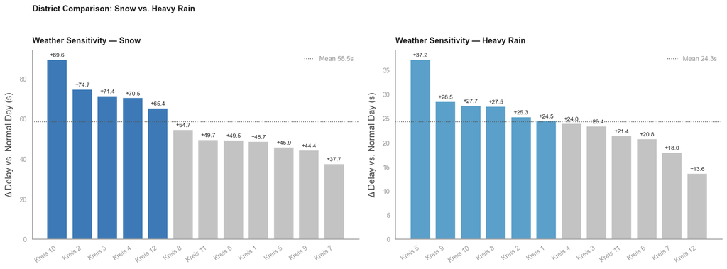

| District | Δ Schnee (s) | Δ Starkregen (s) |
| --- | --- | --- |
| Kreis 7 | 37.70 | 18.00 |
| Kreis 9 | 44.40 | 28.50 |
| Kreis 5 | 45.90 | 37.20 |
| Kreis 10 | 89.60 | 27.70 |
| Kreis 8 | 54.70 | 27.50 |
| Kreis 12 | 65.40 | 13.60 |
| Kreis 4 | 70.50 | 24.00 |
| Kreis 2 | 74.70 | 25.30 |
| Kreis 11 | 49.70 | 21.40 |
| Kreis 6 | 49.50 | 20.80 |
| Kreis 1 | 48.70 | 24.50 |
| Kreis 3 | 71.40 | 23.40 |

```python
an.plot_district_weather_sensitivity(lf_clean, cfg)
show_df(an.table_district_weather_sensitivity(lf_clean))
```

**Beobachtung:** Die Sortierung wechselt komplett zwischen Schnee und Regen — ein starkes Signal für topographische Ursachen.

| Stadtkreis | Δ Schnee | Δ Regen | Charakter |
| --- | --- | --- | --- |
| **Kreis 10** | **+89.4s** | +27.5s | Höngg — erhöhte Lage, exponiert |
| **Kreis 5** | +45.5s | **+36.8s** | Escher Wyss — Limmat-Niederung |
| Kreis 12 | +64.8s | +13.0s | Schwamendingen — suburban, erhöht |
| Kreis 4 | +69.9s | +23.5s | Aussersihl — urban, Hardbrücke-Korridor |

**Kernbefund:** Schnee trifft exponierte Höhenlagen (Kreis 10, 12, 4). Regen trifft Flusstäler und Niederlagen (Kreis 5, 9). Die Topographie bestimmt die Wetterempfindlichkeit.

## Haltestellen-Ranking — Schnee vs. Starkregen

Top 20 Haltestellen nach Δ Delay — sortiert, mit Durchschnittslinie. Kreise über dem Durchschnitt hervorgehoben. Beide Wetterereignisse separat — die Reihenfolge ändert sich zwischen Schnee und Starkregen.

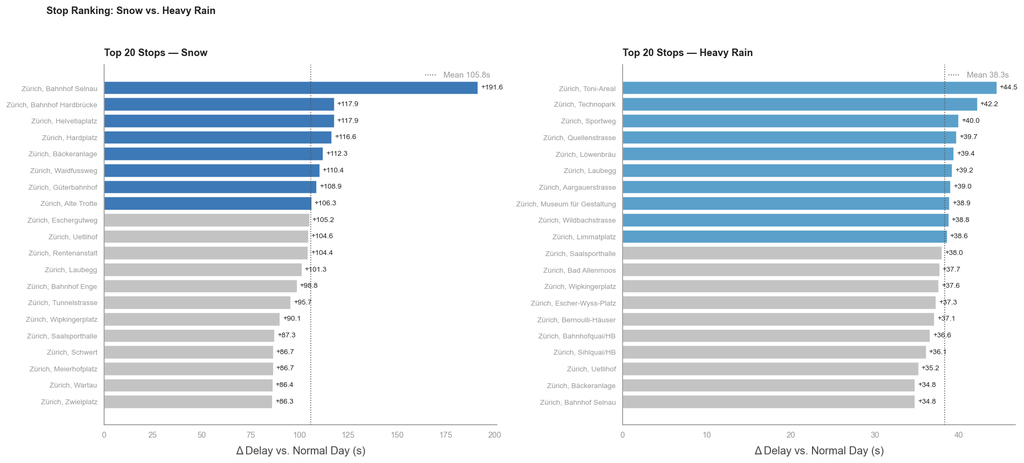

| Stop | Δ Schnee (s) | Δ Starkregen (s) |
| --- | --- | --- |
| Zürich, Bahnhof Selnau | 191.60 | 34.80 |
| Zürich, Rentenanstalt | 104.40 | nan |
| Zürich, Alte Trotte | 106.30 | nan |
| Zürich, Löwenbräu | nan | 39.40 |
| Zürich, Güterbahnhof | 108.90 | nan |
| Zürich, Tunnelstrasse | 95.70 | nan |
| Zürich, Helvetiaplatz | 117.90 | nan |
| Zürich, Zwielplatz | 86.30 | nan |
| Zürich, Bahnhofquai/HB | nan | 36.60 |
| Zürich, Quellenstrasse | nan | 39.70 |
| Zürich, Bernoulli-Häuser | nan | 37.10 |
| Zürich, Uetlihof | 104.60 | 35.20 |
| Zürich, Museum für Gestaltung | nan | 38.90 |
| Zürich, Waidfussweg | 110.40 | nan |
| Zürich, Bad Allenmoos | nan | 37.70 |
| Zürich, Technopark | nan | 42.20 |
| Zürich, Eschergutweg | 105.20 | nan |
| Zürich, Aargauerstrasse | nan | 39.00 |
| Zürich, Meierhofplatz | 86.70 | nan |
| Zürich, Bäckeranlage | 112.30 | nan |
| Zürich, Toni-Areal | nan | 44.50 |
| Zürich, Wartau | 86.40 | nan |
| Zürich, Schwert | 86.70 | nan |
| Zürich, Wipkingerplatz | 90.10 | 37.60 |
| Zürich, Bahnhof Hardbrücke | 117.90 | nan |
| Zürich, Bahnhof Enge | 98.80 | nan |
| Zürich, Sportweg | nan | 40.00 |
| Zürich, Saalsporthalle | 87.30 | 38.00 |
| Zürich, Wildbachstrasse | nan | 38.80 |
| Zürich, Escher-Wyss-Platz | nan | 37.30 |
| Zürich, Laubegg | 101.30 | 39.20 |
| Zürich, Grünaustrasse | nan | 34.80 |
| Zürich, Sihlquai/HB | nan | 36.10 |
| Zürich, Limmatplatz | nan | 38.60 |
| Zürich, Hardplatz | 116.60 | nan |

```python
an.plot_stop_weather_ranking(lf_clean, cfg)
show_df(an.table_stop_weather_ranking(lf_clean))
```

**Beobachtung:** Schnee und Regen treffen komplett verschiedene Haltestellen — kaum Überschneidung in den Top 20.

**Schnee-Ausreisser: Bahnhof Selnau (+190.9s)** Normal 55.6s → Schnee 246.5s — fast 4× der Normalverzögerung. Einzige Haltestelle in dieser Größenordnung. Selnau liegt am Sihl-Ufer und ist Endpunkt mehrerer Linien; Verzögerungen akkumulieren sich dort. Starker Kandidat für operative Maßnahmen bei Schneeereignissen.

**Schnee-Cluster Kreis 4:** Helvetiaplatz, Bahnhof Hardbrücke, Hardplatz, Bäckeranlage — alle ~115s Delta. Dichter Korridor in Aussersihl.

**Schnee-Cluster Kreis 10:** 8 von 20 Top-Haltestellen in Höngg/Wipkingen — erhöhte Lage, Strecken besonders exponiert.

**Regen-Cluster Kreis 5:** 11 von 20 Top-Haltestellen im Escher Wyss / Toni-Areal Korridor. Toni-Areal +44.2s, Technopark +42.0s — Limmat-Niederung mit Drainage-Problemen bei Starkregen.

→ Räumlich trennscharf: Schnee = Höhenlagen, Regen = Limmat-Korridor.

## Linien-Betroffenheit — Welche Linien leiden am meisten?

Δ Delay pro Linie an Schnee- und Starkregen-Tagen. Zeigt welche Linien besonders wetterempfindlich sind — und ob die Reihenfolge zwischen Schnee und Regen wechselt.

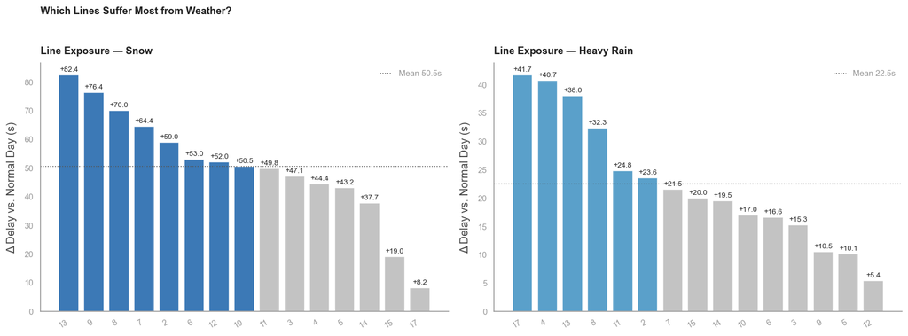

| Line | Δ Schnee (s) | Δ Starkregen (s) |
| --- | --- | --- |
| 13 | 82.40 | 38.00 |
| 9 | 76.40 | 10.50 |
| 8 | 70.00 | 32.30 |
| 7 | 64.40 | 21.50 |
| 2 | 59.00 | 23.60 |
| 6 | 53.00 | 16.60 |
| 12 | 52.00 | 5.40 |
| 10 | 50.50 | 17.00 |
| 11 | 49.80 | 24.80 |
| 3 | 47.10 | 15.30 |
| 4 | 44.40 | 40.70 |
| 5 | 43.20 | 10.10 |
| 14 | 37.70 | 19.50 |
| 15 | 19.00 | 20.00 |
| 17 | 8.20 | 41.70 |

```python
an.plot_line_weather_exposure(lf_clean, cfg)
show_df(an.table_line_weather_exposure(lf_clean))
```

**Beobachtung:** Die Linien-Reihenfolge wechselt zwischen Schnee und Regen drastisch — das stärkste Muster im gesamten Wetter-Notebook.

| Linie | Δ Schnee | Δ Regen | Charakteristik |
| --- | --- | --- | --- |
| **13** | **+82.1s** | +37.7s | Hoch bei beiden — kreuzt beide Zonen |
| **9** | +75.9s | +10.0s | Schnee-Linie — Triemli, erhöhte Lagen |
| **17** | +7.7s | **+41.2s** | Regen-Linie — flache Limmat-Route durch Kreis 5 |
| **12** | +51.7s | +5.0s | Stärkster Gegensatz — Schwamendingen/Northeast |
| **4** | +44.2s | +40.4s | Ausgeglichen hoch — zentrale Achse |

**Kernbefund:** Linie 17 ist der klarste Beweis — Schnee fast irrelevant (+7.7s), Regen Platz 1 (+41.2s). Route führt flach durch den Escher Wyss / Kreis 5 Korridor. Linie 9 und 12 sind das Gegenteil: erhöhte Strecken, stark bei Schnee, kaum bei Regen.

→ Topographie des Linienverlaufs bestimmt die Wetterempfindlichkeit der Linie. Vorhersagemodell könnte davon profitieren: Linie + Wettertyp als Interaktionsterm.

## Multikollinearität — Wetter × Saison

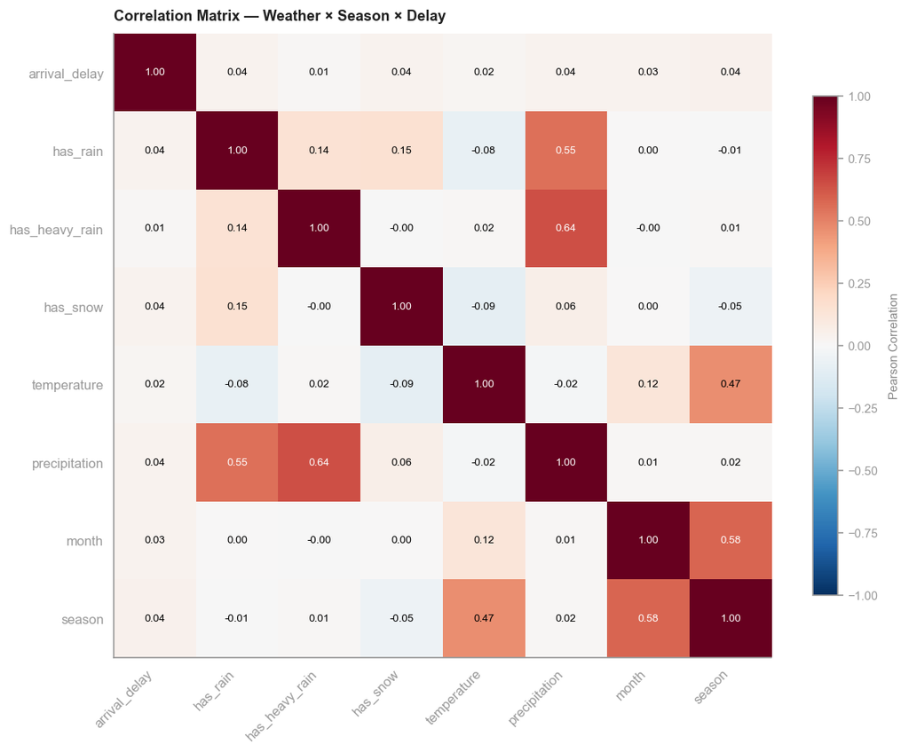

```
Korrelation mit arrival_delay (abs. sortiert):
  season                   : +0.042  (abs: 0.042)
  has_snow                 : +0.038  (abs: 0.038)
  precipitation            : +0.036  (abs: 0.036)
  has_rain                 : +0.036  (abs: 0.036)
  month                    : +0.034  (abs: 0.034)
  temperature              : +0.018  (abs: 0.018)
  has_heavy_rain           : +0.015  (abs: 0.015)

Wetter-Flags × Saison-Korrelation:
  has_rain             × season: -0.006
  has_heavy_rain       × season: +0.012
  has_snow             × season: -0.048
```

| Feature | Korrelation mit delay | \|Korrelation\| |
| --- | --- | --- |
| season | 0.04 | 0.04 |
| has_snow | 0.04 | 0.04 |
| precipitation | 0.04 | 0.04 |
| has_rain | 0.04 | 0.04 |
| month | 0.03 | 0.03 |
| temperature | 0.02 | 0.02 |
| has_heavy_rain | 0.01 | 0.01 |

```python
an.plot_multicollinearity_matrix(lf_delay, cfg)
show_df(an.table_correlation_with_delay(lf_delay))
```

**Beobachtung:** Die Korrelationsmatrix bestätigt die erwarteten Zusammenhänge.

**Korrelation mit `arrival_delay` (abs. sortiert):**

→ Wetter-Features sind schwache aber valide Prädiktoren; Multikollinearität mit Saison-Features beim Modellbau beachten.

## Schnee-Verstärker: Strukturelle Verstärkung bei Schnee

Schnee verursacht nicht nur externen Zusatz-Delay — er verstärkt auch den **strukturellen Aufbau-Mechanismus** im Netz.

Jede Haltestelle akkumuliert unter Schnee durchschnittlich **+33 % mehr Delay** als bei Normalbedingungen (`delay_delta`: 4.95 s → 6.58 s/Halt). Für Fahrgäste ergibt sich am Ende der Fahrt ein Zusatz-Impact von **+54 s** Arrival Delay.

Zwei Panels: (1) Akkumulationsrate pro Halt — strukturelle Verstärkung · (2) Sichtbarer Fahrgast-Impact.

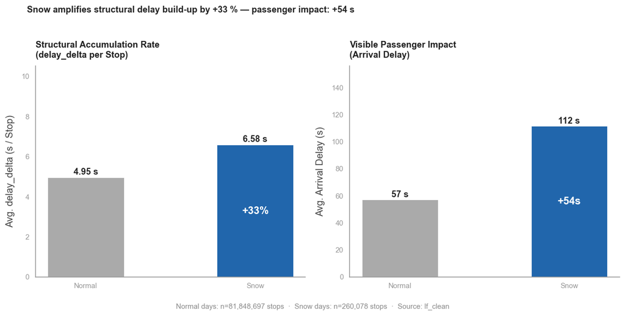

```python
an.plot_snow_structural_interaction(lf_clean)
```

## Key Findings

→ Vollständige Findings-Tabelle mit Impact und Action in `03_analysis_0-overview.ipynb`.

`Präsentation`: **hot** = Kernbefund für Präsentation · **story** = gutes Narrativ · **—** = intern/Feature-Engineering

[output not shown]